# Lab 8 - ANOVA, chi-square, beeswarm

Amelia Ritger

11/19/2019

#### 1. read in data (penguins.csv)

```r
peng <- read_csv("penguins.csv") %>%
  janitor::clean_names()
```

#### 2. find counts of penguins by sex and species

```r
peng_counts <- peng %>%
  count(species,sex)
peng_counts
```

```
## # A tibble: 9 x 3
##   species                                   sex        n
##   <chr>                                     <chr>  <int>
## 1 Adelie Penguin (Pygoscelis adeliae)       FEMALE    73
## 2 Adelie Penguin (Pygoscelis adeliae)       MALE      73
## 3 Adelie Penguin (Pygoscelis adeliae)       <NA>       6
## 4 Chinstrap penguin (Pygoscelis antarctica) FEMALE    34
## 5 Chinstrap penguin (Pygoscelis antarctica) MALE      34
## 6 Gentoo penguin (Pygoscelis papua)         .          1
## 7 Gentoo penguin (Pygoscelis papua)         FEMALE    58
## 8 Gentoo penguin (Pygoscelis papua)         MALE      61
## 9 Gentoo penguin (Pygoscelis papua)         <NA>       4
```

#### 3. compare flipper sizes for female penguins across the 3 species

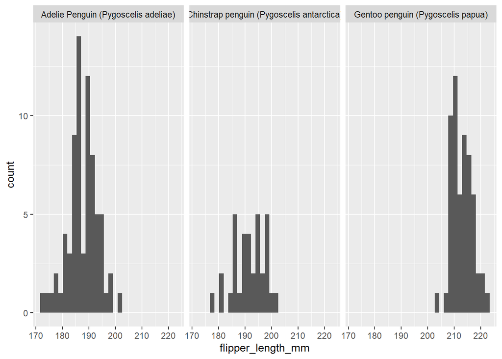

```r
peng_f <- peng %>%
  filter(sex=="FEMALE")

#faceted histogram
ggplot(data=peng_f, aes(x=flipper_length_mm)) +
  geom_histogram() +
  facet_wrap(~species)
```

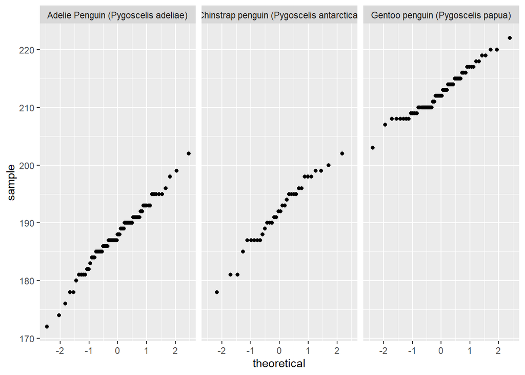

```r
#faceted qq plot
ggplot(data=peng_f, aes(sample= flipper_length_mm)) +
  geom_qq() +
  facet_wrap(~species)
```

### 4. Find summary statistics

```r
peng_f_summary <- peng_f %>%
  group_by(species) %>%
  summarize(mean_flipper_length = mean(flipper_length_mm),
            sd_flipper_length = sd(flipper_length_mm),
            sample_size = n(),
            se_flipper_length = sd(flipper_length_mm)/sqrt(n()),
            varflipper_length = var(flipper_length_mm))
```

Levene’s Test (hypothesis test for equal variances):

```r
# H0: group variances are equal
leveneTest(flipper_length_mm~species, data=peng_f)
```

```
## Levene's Test for Homogeneity of Variance (center = median)
##        Df F value  Pr(>F)
## group   2  2.9012 0.05782 .
##       162
## ---
## Signif. codes:  0 '***' 0.001 '**' 0.01 '*' 0.05 '.' 0.1 ' ' 1
```

Conclusion: Retain the null hypothesis that variances are equal.

Ok, I’ve done my exploratory analysis, and ALL of these pieces combined are making me think that a one-way ANOVA is an appropriate way to compare means between the 3 species.

#### 5. Make a beeswarm plot with the mean and standard deviation overlayed on top of it

The three most common error bars:

- standard deviation (measure of spread)
- standard error (how far our estimate is from true population)
- confidence interval

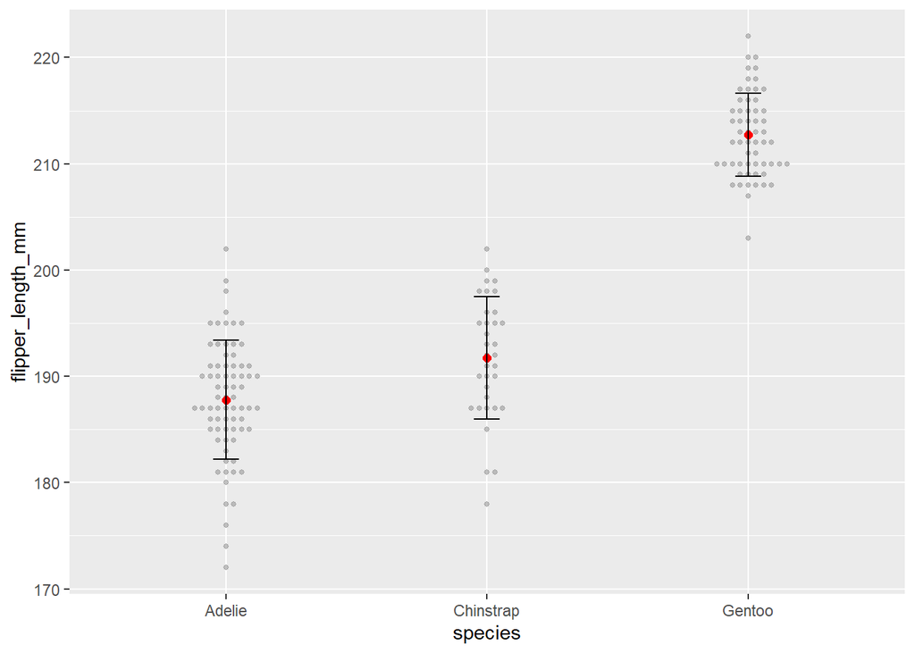

```r
ggplot() +
  geom_beeswarm(data=peng_f,
                aes(x=species, y=flipper_length_mm),
                size=1,
                alpha=0.6,
                color="gray60") +
  scale_x_discrete(labels=c("Adelie", "Chinstrap", "Gentoo")) +
  geom_point(data=peng_f_summary,
             aes(x=species, y=mean_flipper_length),
             color="red",
             size=2) +
  geom_errorbar(data=peng_f_summary,
                aes(x=species,
                    ymin=mean_flipper_length - sd_flipper_length,
                    ymax=mean_flipper_length + sd_flipper_length),
                width=0.1)
```

#### One-way ANOVA

Is there a significant difference in mean flipper length for female penguins between the three species?

```r
peng_aov <- aov(flipper_length_mm ~ species, data=peng_f)
summary(peng_aov)
```

```
##              Df Sum Sq Mean Sq F value Pr(>F)
## species       2  21416   10708   411.8 <2e-16 ***
## Residuals   162   4213      26
## ---
## Signif. codes:  0 '***' 0.001 '**' 0.01 '*' 0.05 '.' 0.1 ' ' 1
```

H0: Means are equal across all groups HA: Means are not equal across all groups (at least two differ)

Conclusion: The mean flipper length for the three species for female penguins are NOT equal.

… so then which ones differ significantly?

Answer that with a post-hoc pairwise comparisons test!

```r
TukeyHSD(peng_aov)
```

```
##   Tukey multiple comparisons of means
##     95% family-wise confidence level
##
## Fit: aov(formula = flipper_length_mm ~ species, data = peng_f)
##
## $species
##                                                                                    diff
## Chinstrap penguin (Pygoscelis antarctica)-Adelie Penguin (Pygoscelis adeliae)  3.940774
## Gentoo penguin (Pygoscelis papua)-Adelie Penguin (Pygoscelis adeliae)         24.912376
## Gentoo penguin (Pygoscelis papua)-Chinstrap penguin (Pygoscelis antarctica)   20.971602
##                                                                                     lwr
## Chinstrap penguin (Pygoscelis antarctica)-Adelie Penguin (Pygoscelis adeliae)  1.436275
## Gentoo penguin (Pygoscelis papua)-Adelie Penguin (Pygoscelis adeliae)         22.790647
## Gentoo penguin (Pygoscelis papua)-Chinstrap penguin (Pygoscelis antarctica)   18.366227
##                                                                                     upr
## Chinstrap penguin (Pygoscelis antarctica)-Adelie Penguin (Pygoscelis adeliae)  6.445272
## Gentoo penguin (Pygoscelis papua)-Adelie Penguin (Pygoscelis adeliae)         27.034105
## Gentoo penguin (Pygoscelis papua)-Chinstrap penguin (Pygoscelis antarctica)   23.576977
##                                                                                   p adj
## Chinstrap penguin (Pygoscelis antarctica)-Adelie Penguin (Pygoscelis adeliae) 0.0007922
## Gentoo penguin (Pygoscelis papua)-Adelie Penguin (Pygoscelis adeliae)         0.0000000
## Gentoo penguin (Pygoscelis papua)-Chinstrap penguin (Pygoscelis antarctica)   0.0000000
```

```r
# diff is the actual difference in means between the two groups
# lwr and upr represent 95% CI on difference between groups
# p adj tells you if there is a sig diff between each pair being compared
```

**Comparing this with the beeswarm plot above… this is good evidence for with large sample sizes, you can find significant ANYTHING. Thus it’s important to also include effect sizes, etc!**

#### 7. Making nicer tables (with proportions)

```r
party_relig <- gss_cat %>%
  filter(partyid %in% c("Strong republican", "Strong democrat")) %>%
  filter(relig %in% c("None", "Catholic")) %>%
  count(partyid, relig)

# check to see what observations you have retained after filtering, etc
unique(party_relig$partyid)
```

```
## [1] Strong republican Strong democrat
## 10 Levels: No answer Don't know Other party ... Strong democrat
```

```r
party_relig_table <- party_relig %>%
  pivot_wider(names_from=relig, values_from=n)
```

#### 8. Make a nice table of proportions using janitor::adorn_*

```r
party_relig_props <- party_relig_table %>%
  adorn_percentages(denominator="row") %>% #convert to percentages
  adorn_pct_formatting(digits=1) %>% #dictate sig figs
  adorn_ns(position="front") #show counts follow by percentages

party_relig_props #boo! it doesn't look as good as I wanted it to!
```

```
##            partyid        None    Catholic
##  Strong republican 117 (19.6%) 481 (80.4%)
##    Strong democrat 554 (43.5%) 720 (56.5%)
```

```r
kable(party_relig_props) %>%
  kable_styling()
```

| partyid | None | Catholic |
| --- | --- | --- |
| Strong republican | 117 (19.6%) | 481 (80.4%) |
| Strong democrat | 554 (43.5%) | 720 (56.5%) |

Here are a few different ways to ask a question for this scenario:

- Are political and religious affiliation independent from each other?
- Is there a significan association between political affiliation and religious affiliation?
- Is there a significant effect of political association (strong republican vs strong democrat) on religoius affiliation (none, catholic)?
- Is there a significant difference in religoius affiliation between strong republicans and strong democrats?

**AKA are the proportions that exist across groups so different that we think the two groups are not independent of one another?**

```r
# Make this a contingency table that ONLY contains the actual counts
chi_counts <- party_relig_table %>%
  select(-partyid)
```

H0:

- There is no signfiicant association between party affiliation and religious affiliation
- There is no significant difference in religious affiliation between the two party groups (str repub or str dem)
- Party and religious affiliation are independent

```r
my_party_chi <- chisq.test(chi_counts)
```